# Introduction to qptools

### parameter tables - extra

```r
"run103" %>% nm_params_table %>%
  lol %>%
  format(paste_label_unit='symbol', pretty=FALSE) %>%
  filter(on==0)
```

```
##         Name pclass on     Estimate se_est       cond om_sg se_om_sg fix term
## 1     THETA1  THETA  0         2.27    --- 25.9927000     0    0e+00   0    0
## 2     THETA2  THETA  0         74.3    ---  0.0964827     0    0e+00   0   37
## 3     THETA3  THETA  0          468    ---  2.5078500     0    0e+00   0    0
## 4     THETA4  THETA  0       0.0714    ---  0.0000000     0    0e+00   0    0
## 5     THETA5  THETA  0         1.09    ---  0.0000000     0    0e+00   0    0
## 6     THETA6  THETA  0        0.745    ---  0.0000000     0    0e+00   0    0
## 7     THETA7  THETA  0        0.587    ---  0.0000000     0    0e+00   0    0
## 8 OMEGA(2,1)  OMEGA  0 0.00 (fixed)      -  0.0000000     0    1e+10   1    0
##   part_deriv_LL fr sr type Shrinkage  RSE        95\\% CI        item
## 1   5.48200e-06 NA NA           0.00 3.55     2.11 - 2.43    theta_01
## 2   9.29421e-06 NA NA           0.00 5.06     66.9 - 81.6    theta_02
## 3   1.49913e-06 NA NA           0.00 6.04       413 - 524    theta_03
## 4   4.28314e-02 NA NA           0.00 11.5 0.0553 - 0.0875    theta_04
## 5   5.83685e-03 NA NA           0.00 7.85    0.925 - 1.26    theta_05
```

[output cut: 21 more lines]

format with pretty = FALSE ensures that the formatting is performed but no column is removed. This leaves one with everything one can imagine, even the functions used for transformation. Explore the table provided and see how one can shrink it using `filter(on==0 or 1)` (include / exclude off-diagonals while keeping the THETAs of course) or `filter(fix=0 or 1)` to focus on (non-)estimated parameters.

Check `?format.nmpartab` for useful arguments and examples.

## Show the modeled data

Looking at the NONMEM analysis data with or without the `$IGNORE` and `$ACCEPT` components applied.

```r
"run105" %>% nm_parse_dollar_data
```

```
## $data
## [1] "acop.csv"
##
## $ignores
## [1] ""
##
## $accepts
## NULL
```

```r
"run105" %>% load_modeled_dataset() %>% as_tibble()
```

```
## did not find ../inst/extdata/NONMEM/acop.yaml
```

```
## # A tibble: 800 × 10
##       id  time   mdv  evid    dv   amt   sex    wt   etn   cmt
##    <int> <dbl> <int> <int> <dbl> <int> <int> <dbl> <int> <int>
##  1     1  0        1     1  0    10000     1  51.6     1     1
##  2     1  0        0     0  1.22     0     1  51.6     1     3
##  3     1  0.25     0     0 12.6      0     1  51.6     1     3
##  4     1  0.5      0     0 11.2      0     1  51.6     1     3
##  5     1  0.75     0     0 17.7      0     1  51.6     1     3
##  6     1  1        0     0 21.9      0     1  51.6     1     3
##  7     1  1.25     0     0 16.2      0     1  51.6     1     3
##  8     1  1.5      0     0 18.7      0     1  51.6     1     3
##  9     1  1.75     0     0 23.8      0     1  51.6     1     3
## 10     1  2        0     0 16.5      0     1  51.6     1     3
## # ℹ 790 more rows
```

```r
"run105" %>% load_modeled_dataset(visibility = TRUE) %>% as_tibble()
```

```
## did not find ../inst/extdata/NONMEM/acop.yaml
```

```
## # A tibble: 800 × 11
##       id  time   mdv  evid    dv   amt   sex    wt   etn   cmt VISIBLE
##    <int> <dbl> <int> <int> <dbl> <int> <int> <dbl> <int> <int> <dvec>
##  1     1  0        1     1  0    10000     1  51.6     1     1 1
##  2     1  0        0     0  1.22     0     1  51.6     1     3 1
##  3     1  0.25     0     0 12.6      0     1  51.6     1     3 1
##  4     1  0.5      0     0 11.2      0     1  51.6     1     3 1
##  5     1  0.75     0     0 17.7      0     1  51.6     1     3 1
##  6     1  1        0     0 21.9      0     1  51.6     1     3 1
##  7     1  1.25     0     0 16.2      0     1  51.6     1     3 1
##  8     1  1.5      0     0 18.7      0     1  51.6     1     3 1
##  9     1  1.75     0     0 23.8      0     1  51.6     1     3 1
## 10     1  2        0     0 16.5      0     1  51.6     1     3 1
## # ℹ 790 more rows
```

```r
"run105" %>% load_modeled_dataset(visibility = TRUE) %>% decorations
```

```
## did not find ../inst/extdata/NONMEM/acop.yaml
```

```
## - id:
## - time:
## - mdv:
## - evid:
## - dv:
## - amt:
## - sex:
## - wt:
## - etn:
## - cmt:
## - VISIBLE
##  - label: Record Visibility
##  - guide
##   - Ignored: 0
##   - Visible: 1
```

```r
## VISIBLE shows original dataset marked for included (VISIBLE=1) or excluded (VISIBLE=0) in the NONMEM model.


1001 %>% get_xpose_tables(x=.,directory=system.file('project/model',package='nonmemica'))
```

```
## # A tibble: 550 × 19
##       ID   AMT  TIME  EVID  IPRE CWRESI  CIWRESI    DV  PRED    RES     WRES
##    <dbl> <dbl> <dbl> <dbl> <dbl>  <dbl>    <dbl> <dbl> <dbl>  <dbl>    <dbl>
##  1     1  1000  0        1 0      0      0       0     0      0      0
##  2     1     0  0.25     0 0.365 -0.171 -0.00372 0.363 0.721 -0.358 -0.0832
##  3     1     0  0.5      0 0.687  0.149  0.479   0.914 1.33  -0.415  0.256
##  4     1     0  1        0 1.22  -0.580 -0.193   1.12  2.27  -1.15  -0.408
##  5     1     0  2        0 1.95  -0.107  0.526   2.28  3.37  -1.09   0.00381
##  6     1     0  3        0 2.37  -1.28  -1.07    1.63  3.83  -2.20  -1.07
##  7     1     0  4        0 2.60  -1.01  -0.762   2.04  3.97  -1.93  -0.842
##  8     1     0  6        0 2.72  -1.48  -1.48    1.61  3.80  -2.19  -1.32
##  9     1     0  8        0 2.65  -0.157  0.105   2.73  3.45  -0.720 -0.0508
## 10     1     0 12        0 2.35   0.837  1.07    3.09  2.74   0.348  0.926
## # ℹ 540 more rows
## # ℹ 8 more variables: CL <dbl>, V2 <dbl>, KA <dbl>, Q <dbl>, V3 <dbl>,
## #   ETA1 <dbl>, ETA2 <dbl>, ETA3 <dbl>
```

```r
try(1001 %>% superset(project=system.file('project/model',package='nonmemica'))) # no
```

```
## Error in file(con, "r") : cannot open the connection
```

```r
1001 %>% superset(project=system.file('project/model',package='nonmemica'),ext="ctl") %>% as_tibble # yes
```

```
## # A tibble: 600 × 39
##    C        ID  TIME   SEQ  EVID AMT   DV     SUBJ  HOUR HEIGHT WEIGHT   SEX
##    <chr> <int> <dbl> <int> <int> <chr> <chr> <int> <dbl>  <int>  <dbl> <int>
##  1 C         1  0        0     0 .     0         1  0       174   74.2     0
##  2 .         1  0        1     1 1000  .         1  0       174   74.2     0
##  3 .         1  0.25     0     0 .     0.363     1  0.25    174   74.2     0
##  4 .         1  0.5      0     0 .     0.914     1  0.5     174   74.2     0
##  5 .         1  1        0     0 .     1.12      1  1       174   74.2     0
##  6 .         1  2        0     0 .     2.28      1  2       174   74.2     0
##  7 .         1  3        0     0 .     1.63      1  3       174   74.2     0
##  8 .         1  4        0     0 .     2.04      1  4       174   74.2     0
##  9 .         1  6        0     0 .     1.61      1  6       174   74.2     0
## 10 .         1  8        0     0 .     2.73      1  8       174   74.2     0
## # ℹ 590 more rows
## # ℹ 27 more variables: AGE <dbl>, DOSE <dbl>, FED <int>, SMK <int>, DS <int>,
## #   CRCN <dbl>, TAFD <dbl>, TAD <chr>, LDOS <chr>, MDV <int>, predose <int>,
## #   zerodv <int>, VISIBLE <int>, IPRE <dbl>, CWRESI <dbl>, CIWRESI <dbl>,
## #   PRED <dbl>, RES <dbl>, WRES <dbl>, CL <dbl>, V2 <dbl>, KA <dbl>, Q <dbl>,
## #   V3 <dbl>, ETA1 <dbl>, ETA2 <dbl>, ETA3 <dbl>
```

## Load output dataset using get_xpose_tables()

```r
"run103" %>% get_xpose_tables
```

```
## # A tibble: 800 × 20
##       ID   SEX   ETN    DV  PRED    RES   WRES    WT    CL     V    KA    ETA1
##    <dbl> <dbl> <dbl> <dbl> <dbl>  <dbl>  <dbl> <dbl> <dbl> <dbl> <dbl>   <dbl>
##  1     1     1     1  0     0     0      0      51.6  31.9  468.  2.27 -0.0854
##  2     1     1     1  1.22  0     1.22   1.11   51.6  31.9  468.  2.27 -0.0854
##  3     1     1     1 12.6   9.16  3.41   1.93   51.6  31.9  468.  2.27 -0.0854
##  4     1     1     1 11.2  14.2  -2.96  -1.39   51.6  31.9  468.  2.27 -0.0854
##  5     1     1     1 17.7  16.9   0.844  0.348  51.6  31.9  468.  2.27 -0.0854
##  6     1     1     1 21.9  18.2   3.70   1.50   51.6  31.9  468.  2.27 -0.0854
##  7     1     1     1 16.2  18.8  -2.63  -1.08   51.6  31.9  468.  2.27 -0.0854
##  8     1     1     1 18.7  19.0  -0.331 -0.162  51.6  31.9  468.  2.27 -0.0854
##  9     1     1     1 23.8  19.0   4.81   1.90   51.6  31.9  468.  2.27 -0.0854
## 10     1     1     1 16.5  18.8  -2.33  -0.978  51.6  31.9  468.  2.27 -0.0854
## # ℹ 790 more rows
## # ℹ 8 more variables: ETA2 <dbl>, TIME <dbl>, MDV <dbl>, EVID <dbl>,
## #   IPRED <dbl>, IWRES <dbl>, CWRES <dbl>, DV.1 <dbl>
```

```r
paste0("run", c(100,103,105)) %>% lapply(., function(x) get_xpose_tables(x))
```

```
## [[1]]
## # A tibble: 800 × 20
##       ID   SEX   ETN    DV  PRED     RES   WRES    WT    CL     V    KA   ETA1
##    <dbl> <dbl> <dbl> <dbl> <dbl>   <dbl>  <dbl> <dbl> <dbl> <dbl> <dbl>  <dbl>
##  1     1     1     1  0     0     0       0      51.6  31.8  469.  2.27 -0.285
##  2     1     1     1  1.22  0     1.22    1.11   51.6  31.8  469.  2.27 -0.285
##  3     1     1     1 12.6   9.14  3.42    1.92   51.6  31.8  469.  2.27 -0.285
##  4     1     1     1 11.2  14.1  -2.90   -1.41   51.6  31.8  469.  2.27 -0.285
##  5     1     1     1 17.7  16.7   0.979   0.344  51.6  31.8  469.  2.27 -0.285
##  6     1     1     1 21.9  18.0   3.91    1.51   51.6  31.8  469.  2.27 -0.285
##  7     1     1     1 16.2  18.6  -2.35   -1.09   51.6  31.8  469.  2.27 -0.285
##  8     1     1     1 18.7  18.7   0.0182 -0.153  51.6  31.8  469.  2.27 -0.285
##  9     1     1     1 23.8  18.6   5.23    1.94   51.6  31.8  469.  2.27 -0.285
## 10     1     1     1 16.5  18.3  -1.84   -0.973  51.6  31.8  469.  2.27 -0.285
## # ℹ 790 more rows
## # ℹ 8 more variables: ETA2 <dbl>, TIME <dbl>, MDV <dbl>, EVID <dbl>,
## #   IPRED <dbl>, IWRES <dbl>, CWRES <dbl>, DV.1 <dbl>
##
## [[2]]
## # A tibble: 800 × 20
##       ID   SEX   ETN    DV  PRED    RES   WRES    WT    CL     V    KA    ETA1
##    <dbl> <dbl> <dbl> <dbl> <dbl>  <dbl>  <dbl> <dbl> <dbl> <dbl> <dbl>   <dbl>
##  1     1     1     1  0     0     0      0      51.6  31.9  468.  2.27 -0.0854
##  2     1     1     1  1.22  0     1.22   1.11   51.6  31.9  468.  2.27 -0.0854
##  3     1     1     1 12.6   9.16  3.41   1.93   51.6  31.9  468.  2.27 -0.0854
##  4     1     1     1 11.2  14.2  -2.96  -1.39   51.6  31.9  468.  2.27 -0.0854
##  5     1     1     1 17.7  16.9   0.844  0.348  51.6  31.9  468.  2.27 -0.0854
##  6     1     1     1 21.9  18.2   3.70   1.50   51.6  31.9  468.  2.27 -0.0854
##  7     1     1     1 16.2  18.8  -2.63  -1.08   51.6  31.9  468.  2.27 -0.0854
##  8     1     1     1 18.7  19.0  -0.331 -0.162  51.6  31.9  468.  2.27 -0.0854
##  9     1     1     1 23.8  19.0   4.81   1.90   51.6  31.9  468.  2.27 -0.0854
## 10     1     1     1 16.5  18.8  -2.33  -0.978  51.6  31.9  468.  2.27 -0.0854
## # ℹ 790 more rows
## # ℹ 8 more variables: ETA2 <dbl>, TIME <dbl>, MDV <dbl>, EVID <dbl>,
## #   IPRED <dbl>, IWRES <dbl>, CWRES <dbl>, DV.1 <dbl>
##
## [[3]]
## # A tibble: 800 × 20
##       ID   SEX   ETN    DV  PRED    RES   WRES    WT    CL     V    KA    ETA1
##    <dbl> <dbl> <dbl> <dbl> <dbl>  <dbl>  <dbl> <dbl> <dbl> <dbl> <dbl>   <dbl>
##  1     1     1     1  0     0     0      0      51.6  31.9  468.  2.27 -0.0856
##  2     1     1     1  1.22  0     1.22   1.11   51.6  31.9  468.  2.27 -0.0856
##  3     1     1     1 12.6   9.16  3.41   1.93   51.6  31.9  468.  2.27 -0.0856
##  4     1     1     1 11.2  14.2  -2.96  -1.39   51.6  31.9  468.  2.27 -0.0856
##  5     1     1     1 17.7  16.9   0.845  0.348  51.6  31.9  468.  2.27 -0.0856
##  6     1     1     1 21.9  18.2   3.70   1.50   51.6  31.9  468.  2.27 -0.0856
##  7     1     1     1 16.2  18.8  -2.63  -1.08   51.6  31.9  468.  2.27 -0.0856
##  8     1     1     1 18.7  19.0  -0.331 -0.162  51.6  31.9  468.  2.27 -0.0856
##  9     1     1     1 23.8  19.0   4.81   1.90   51.6  31.9  468.  2.27 -0.0856
## 10     1     1     1 16.5  18.8  -2.33  -0.978  51.6  31.9  468.  2.27 -0.0856
## # ℹ 790 more rows
## # ℹ 8 more variables: ETA2 <dbl>, TIME <dbl>, MDV <dbl>, EVID <dbl>,
## #   IPRED <dbl>, IWRES <dbl>, CWRES <dbl>, DV.1 <dbl>
```

```
## = 'y ~ x'
```

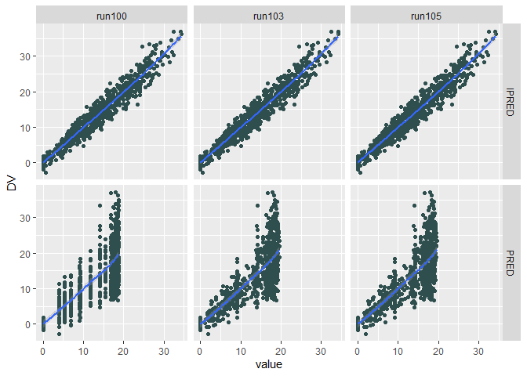

```r
library(ggplot2)
library(tidyr)
paste0("run", c(100,103,105)) %>% lapply(., function(x) get_xpose_tables(x) %>% mutate(model=x)) -> tmp
do.call("rbind", tmp) %>%
  pivot_longer(cols = c(IPRED,PRED)) %>%
  ggplot(aes(y=DV,x=value)) +
  geom_point(col = "darkslategrey") +
  stat_smooth(method='loess', alpha=0.33) +
  facet_grid(name~model)
```

`get_xpose_tables` is like get.xpose.tables from qpToolkit, but even more foolproof (non-xpose table names, column names nearly similar) and this returning a tibble for clear print results / overview.

## Make a Runrecord

Using `nm_runrecord`.

By default the last estimation method from each run is used to compile the runrecord.

```r
paste0("run", 100:105) %>% nm_runrecord()
```

```
##   Run Ref    OFV  dOFV  meth lap min rerr   cn     data nids nobs nth nom nsg
## 1 100   0 2085.6    NA focei  no   1    0 15.8 acop.csv   40  760 5/5 2/3 0/1
## 2 101 100 2076.5  -9.1 focei  no   1    0 30.2 acop.csv   40  760 6/6 2/3 0/1
## 3 102 100 2077.1  -8.5 focei  no   1    0 17.5 acop.csv   40  760 5/6 2/3 0/1
## 4 103 101 2041.8 -34.7 focei  no   1    0   26 acop.csv   40  760 7/7 2/3 0/1
## 5 105 102 2041.8 -35.3 focei  no   1    0 18.8 acop.csv   40  760 6/7 2/3 0/1
##   npar                         Description
## 1  7/9             PK model 1 cmt  - base
## 2 8/10             PK model 1 cmt - WT-CL
## 3 7/10    PK model 1 cmt - WT-CL allometry
## 4 9/11       PK model 1 cmt - WT-CL SEX-CL
## 5 8/11 PK model 1 cmt - WT-CL allom SEX-CL
```

```r
paste0("run", 100:105) %>% nm_runrecord(. ,index = c(1,3,3))
```

```
## index supplied not of same length as number of parseable runs. Defaulting to last estimation method of each run.
```

```
##   Run Ref    OFV  dOFV  meth lap min rerr   cn     data nids nobs nth nom nsg
## 1 100   0 2085.6    NA focei  no   1    0 15.8 acop.csv   40  760 5/5 2/3 0/1
## 2 101 100 2076.5  -9.1 focei  no   1    0 30.2 acop.csv   40  760 6/6 2/3 0/1
## 3 102 100 2077.1  -8.5 focei  no   1    0 17.5 acop.csv   40  760 5/6 2/3 0/1
## 4 103 101 2041.8 -34.7 focei  no   1    0   26 acop.csv   40  760 7/7 2/3 0/1
## 5 105 102 2041.8 -35.3 focei  no   1    0 18.8 acop.csv   40  760 6/7 2/3 0/1
##   npar                         Description
## 1  7/9             PK model 1 cmt  - base
## 2 8/10             PK model 1 cmt - WT-CL
## 3 7/10    PK model 1 cmt - WT-CL allometry
## 4 9/11       PK model 1 cmt - WT-CL SEX-CL
## 5 8/11 PK model 1 cmt - WT-CL allom SEX-CL
```

```r
paste0("run", 100:105) %>% nm_runrecord(. ,index = c(1,3,3,2,1))
```

```
##   Run Ref    OFV   dOFV  meth lap min rerr   cn     data nids nobs nth nom nsg
## 1 100   0 1705.6     NA  saem  no   0    0   11 acop.csv   40  760 5/5 2/3 0/1
## 2 101 100 2076.5  370.9 focei  no   1    0 30.2 acop.csv   40  760 6/6 2/3 0/1
## 3 102 100 2077.1  371.5 focei  no   1    0 17.5 acop.csv   40  760 5/6 2/3 0/1
## 4 103 101 2042.7  -33.8 imp-e  no   0    0 25.6 acop.csv   40  760 7/7 2/3 0/1
## 5 105 102 1653.7 -423.4  saem  no   0    0   24 acop.csv   40  760 6/7 2/3 0/1
##   npar                         Description
## 1  7/9             PK model 1 cmt  - base
## 2 8/10             PK model 1 cmt - WT-CL
## 3 7/10    PK model 1 cmt - WT-CL allometry
## 4 9/11       PK model 1 cmt - WT-CL SEX-CL
## 5 8/11 PK model 1 cmt - WT-CL allom SEX-CL
```

```
## = 'loess' and formula = 'y ~
## x'
```

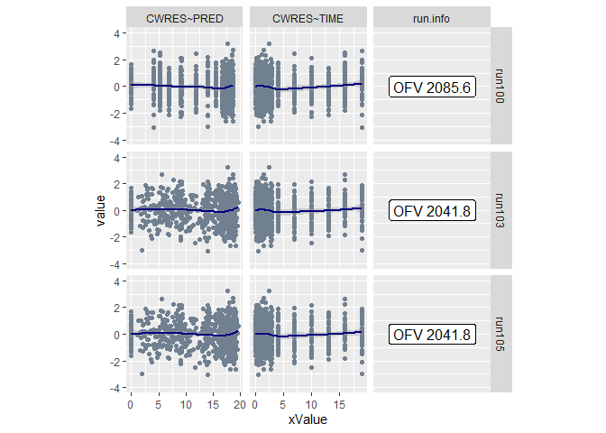

```r
paste0("run", c(100,103,105)) %>% nm_runrecord_graph()
```

## Process an SCM table

There is a 17-character limit to the covariate effect name! So consider using ‘short’ names. As of version 4.5.2, we try to accommodate longer names.

```r
getOption("qpExampleDir") %>% dir
```

```
##  [1] "acop.csv"        "binom.csv"       "bootstrap"       "example1"
##  [5] "example1.csv"    "example1.ctl"    "example1.lst"    "example2"
##  [9] "example2.csv"    "example2.ctl"    "example2.lst"    "example3"
## [13] "example3.csv"    "example3.ctl"    "example3.lst"    "run1"
## [17] "run1.lst"        "run1.mod"        "run100"          "run100.lst"
## [21] "run100.mod"      "run101"          "run101.lst"      "run101.mod"
## [25] "run102"          "run102.lst"      "run102.mod"      "run103"
## [29] "run103.lst"      "run103.mod"      "run105"          "run105.lst"
## [33] "run105.mod"      "run105bs.mod"    "run106"          "run106.lst"
## [37] "run106.mod"      "run107"          "run107.lst"      "run107.mod"
## [41] "run108"          "run108.lst"      "run108.mod"      "scm_config2.scm"
## [45] "scm_example2"
```

```r
## full SCM forward backward and final
nm_process_scm(directory = file.path(getOption("nmDir"),"scm_example2")) %>% as_tibble()
```

```
## # A tibble: 34 × 11
##     step model  ofvbase ofvtest   dofv  goal deltadf significant   pvalue chosen
##    <int> <chr>    <dbl>   <dbl>  <dbl> <dbl>   <int>       <int>    <dbl>  <dbl>
##  1     1 CLAGE…  -5495.  -8792. 3.30e3  6.63       1           1 0             0
##  2     1 CLGND…  -5495.  -9557. 4.06e3  6.63       1           1 0             1
##  3     1 QAGE-5  -5495.  -6123. 6.28e2  6.63       1           1 0             0
##  4     1 QGNDR…  -5495.  -8790. 3.30e3  6.63       1           1 0             0
##  5     1 V1AGE…  -5495.  -9146. 3.65e3  6.63       1           1 0             0
##  6     1 V1GND…  -5495.  -9050. 3.56e3  6.63       1           1 0             0
##  7     1 V2AGE…  -5495.  -8810. 3.32e3  6.63       1           1 0             0
##  8     1 V2GND…  -5495.  -8790. 3.30e3  6.63       1           1 0             0
##  9     2 CLAGE…  -9557.  -9746. 1.89e2  6.63       1           1 4.79e-43      1
## 10     2 QAGE-5  -9557.  -9560. 2.77e0  6.63       1           0 9.60e- 2      0
## # ℹ 24 more rows
## # ℹ 1 more variable: direction <dbl>
```

```r
#now play with chosen, direction to get what you want.

## forward steps
nm_process_scm(directory = file.path(getOption("nmDir"),"scm_example2")) %>% filter(chosen==0&direction==1)
```

```
##    step    model    ofvbase    ofvtest       dofv   goal deltadf significant
## 1     1  CLAGE-5  -5494.546  -8791.872 3297.32607 6.6349       1           1
## 2     1   QAGE-5  -5494.546  -6123.028  628.48146 6.6349       1           1
## 3     1  QGNDR-2  -5494.546  -8789.924 3295.37813 6.6349       1           1
## 4     1  V1AGE-5  -5494.546  -9145.808 3651.26194 6.6349       1           1
## 5     1 V1GNDR-2  -5494.546  -9049.804 3555.25789 6.6349       1           1
## 6     1  V2AGE-5  -5494.546  -8810.115 3315.56884 6.6349       1           1
## 7     1 V2GNDR-2  -5494.546  -8790.222 3295.67624 6.6349       1           1
## 8     2   QAGE-5  -9557.268  -9560.038    2.77025 6.6349       1           0
## 9     2  QGNDR-2  -9557.268  -9559.482    2.21381 6.6349       1           0
## 10    2  V1AGE-5  -9557.268  -9658.181  100.91305 6.6349       1           1
## 11    2 V1GNDR-2  -9557.268  -9565.896    8.62816 6.6349       1           1
## 12    2  V2AGE-5  -9557.268  -9570.108   12.84003 6.6349       1           1
## 13    2 V2GNDR-2  -9557.268  -9557.272    0.00373 6.6349       1           0
## 14    3   QAGE-5  -9746.452  -9746.702    0.25034 6.6349       1           0
```

[output cut: 39 more lines]

```r
## backward steps
nm_process_scm(directory = file.path(getOption("nmDir"),"scm_example2")) %>% filter(direction==-1)
```

```
##   step    model   ofvbase    ofvtest       dofv    goal deltadf significant
## 1    6  CLAGE-1 -10195.28  -9671.863 -523.41471 -10.828      -1           0
## 2    6 CLGNDR-1 -10195.28  -9250.324 -944.95348 -10.828      -1           0
## 3    6  V1AGE-1 -10195.28  -9752.874 -442.40292 -10.828      -1           0
## 4    6 V1GNDR-1 -10195.28 -10169.003  -26.27446 -10.828      -1           0
##     pvalue chosen direction
## 1 0.00e+00      0        -1
## 2 0.00e+00      0        -1
## 3 0.00e+00      0        -1
## 4 2.96e-07      0        -1
```

```r
nm_process_scm(directory = file.path(getOption("nmDir"),"scm_example2")) %>% filter(chosen==0&direction==-1)
```

```
##   step    model   ofvbase    ofvtest       dofv    goal deltadf significant
## 1    6  CLAGE-1 -10195.28  -9671.863 -523.41471 -10.828      -1           0
## 2    6 CLGNDR-1 -10195.28  -9250.324 -944.95348 -10.828      -1           0
## 3    6  V1AGE-1 -10195.28  -9752.874 -442.40292 -10.828      -1           0
## 4    6 V1GNDR-1 -10195.28 -10169.003  -26.27446 -10.828      -1           0
##     pvalue chosen direction
## 1 0.00e+00      0        -1
## 2 0.00e+00      0        -1
## 3 0.00e+00      0        -1
## 4 2.96e-07      0        -1
```

```r
## final model
nm_process_scm(directory = file.path(getOption("nmDir"),"scm_example2")) %>% filter(chosen==1)
```

```
##   step    model    ofvbase    ofvtest       dofv   goal deltadf significant
## 1    1 CLGNDR-2  -5494.546  -9557.268 4062.72165 6.6349       1           1
## 2    2  CLAGE-5  -9557.268  -9746.452  189.18389 6.6349       1           1
## 3    3  V1AGE-5  -9746.452 -10176.099  429.64766 6.6349       1           1
## 4    4 V1GNDR-2 -10176.099 -10195.277   19.17797 6.6349       1           1
##     pvalue chosen direction
## 1 0.00e+00      1         1
## 2 4.79e-43      1         1
## 3 0.00e+00      1         1
## 4 1.20e-05      1         1
```